# Does high satisfaction lead to higher prices?

Determinants of Airbnb Prices in Istanbul and Barcelona

Sıla Erikci

*METU Department of Economics*

June 2019

## About

In recent years, a new business model known as the **sharing economy** has become a major phenomenon. This concept has emerged in the accommodation sector of the tourism and hospitality. Airbnb, like many other platforms *(Uber, Spotify, Lyft)*, has pioneered the use of this business model to connect people who own idle accommodation assets such as empty rooms or apartments with those who need temporary accommodation like tourists via digital platforms. Thus, many people have started to participate in sharing economy platforms because of the economic and financial benefits it provides both for suppliers and consumers. In particular, these platforms provide cost-saving benefits and convenience to the consumers, while allowing suppliers to generate extra income. Therefore, one of the reason for the rapid growth of sharing economy based accommodation rental has been attributed to the provision of a wide range of prices and property features, as well as a more diversified experience than that of conventional hotel accommodation *(Guttentag, 2015; Tussyadiah and Pesonen, 2015; Wang et al., 2016).* Since the market share of this multi-sided platform in accomodation sector is rapidly increasing, discussing what customers value most in Airbnb accommodations and what price determinants are in this marketplace would be highly reasonable.

In the conventional hotel industry, most of the factors determining the price of hotel accomodation are known by both guests and hotel owners. Location, number of stars, amenities such as mini bar, TV, hair dryer and laundry services such as breakfast services are some of the most common ones. However, factors determining prices in Airbnb are much more complex. As consumers care social benefits as much as economic benefits, they may perceive differently the value of services offered through sharing economy platforms than they do the value of traditional businesses. For example, consumers may value the communication, trustworthiness, and friendliness of their Airbnb hosts and the experience they enjoy during their stay *(Mody, Suess, & Lehto, in press).* In addition, as a feedback and self-selection mechanism of Airbnb, when customers leave the house, they can write review and rate their experience on the website of the house by evaluating cleanliness of room, location, communication of host, accuracy of information before reservation, value of the room and check-in experience. All these ratings can give information about consumers’ overall satisfaction. This study investigates effects of overall satisfaction on prices and shows that its effect is not always positively related with price of the rooms per night by comparing two important tourism center, İstanbul and Barcelona.

## Data

### Data Source

- [insideairbnb.com](http://insideairbnb.com/get-the-data.html)
- Downloaded on 5 April 2019
- Listings’ date compiled is March 2019

### Variables

- Price (**turkish lira** for Istanbul, **euro** for Barcelona)
- Room type (Entire home/apartment & Private)
- Number of bedrooms
- Host name
- Host gender (by **gender(host_name)** function)
- Superhost status (true/false)
- Host identity verified (true/false)
- Host has profile picture (true/false)
- Review scores for
  - **cleanliness**
  - **location**
  - **communication**
  - **accuracy**
  - **value**
  - **check-in**
- Overall satisfaction (average of **review scores rating**)
- Cancellation policy (flexible/non-flexible)
- Instant bookable (true/false)
- Longitude
- Latitude

## Descriptives

### Property Attributes

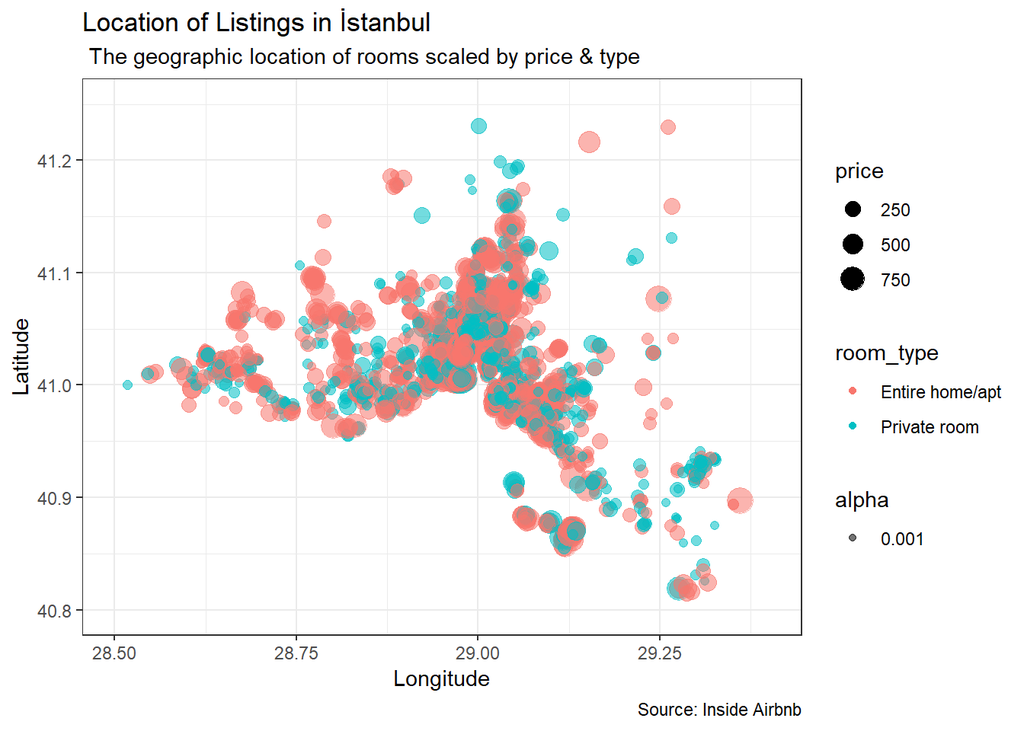

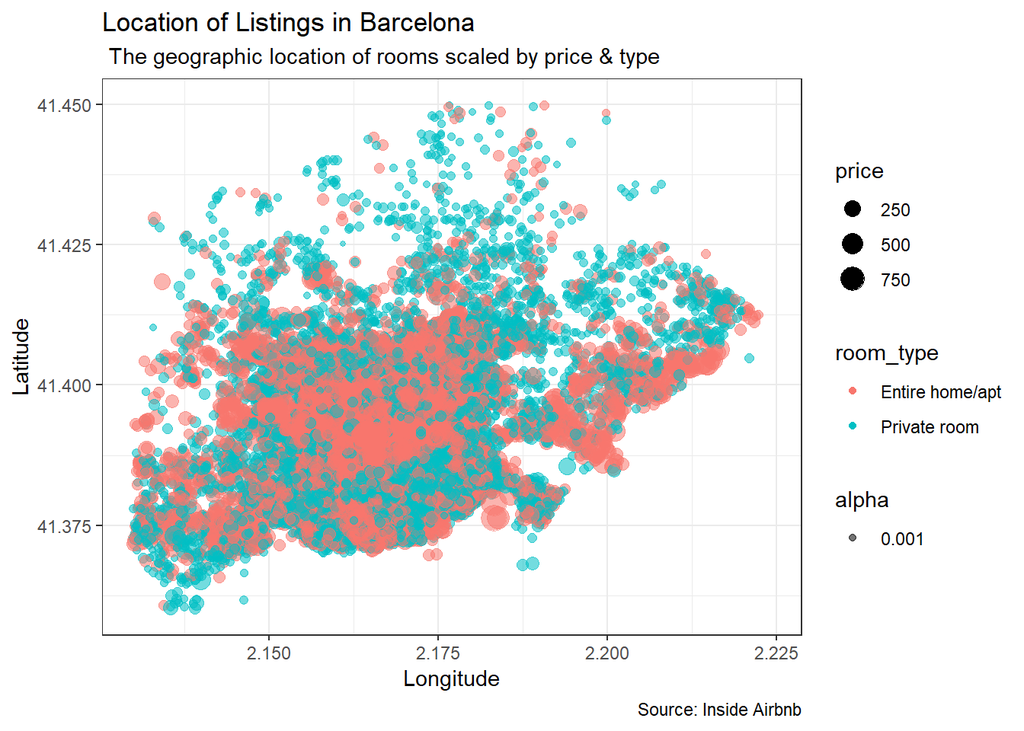

In Airbnb listings, houses are defined in three types: entire home/apartment, private room and shared room. However, since the share of shared room is very low compared to the others, it was not included in the study. The distribution of house types is as follows for both cities:

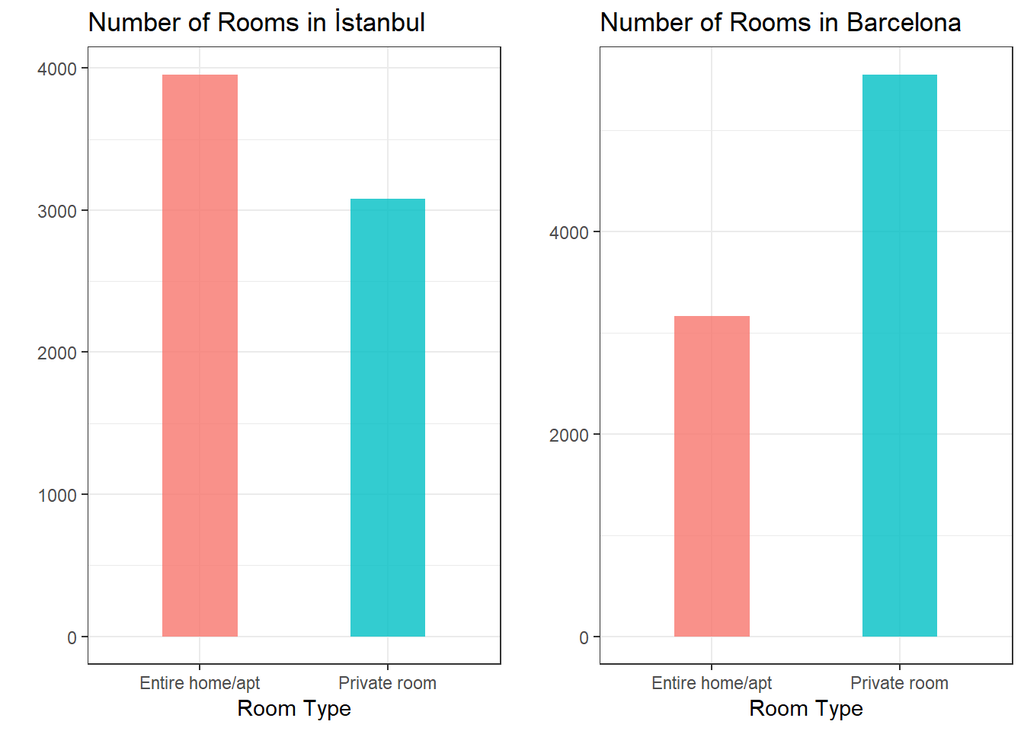

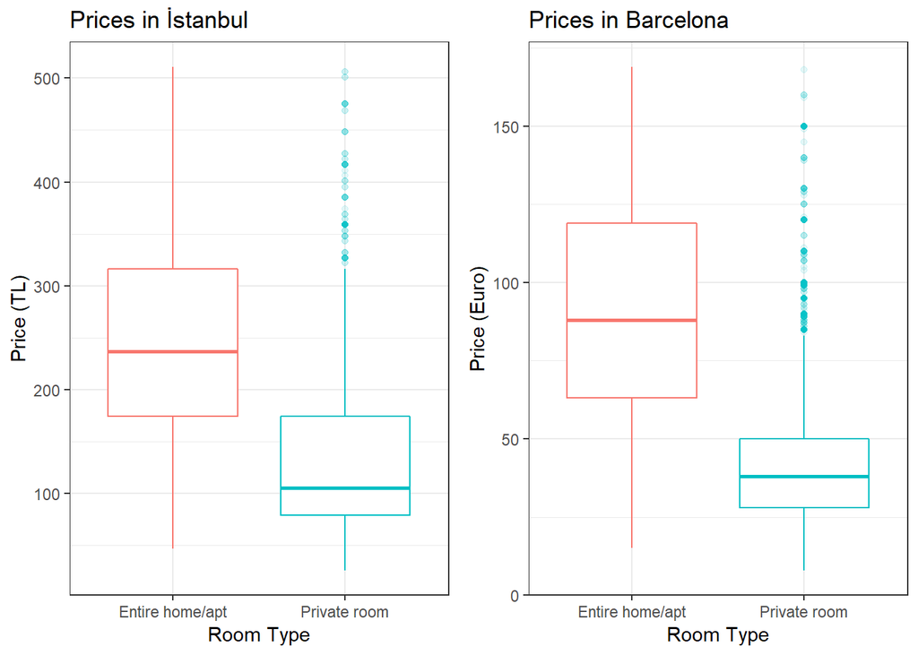

### Host Attributes

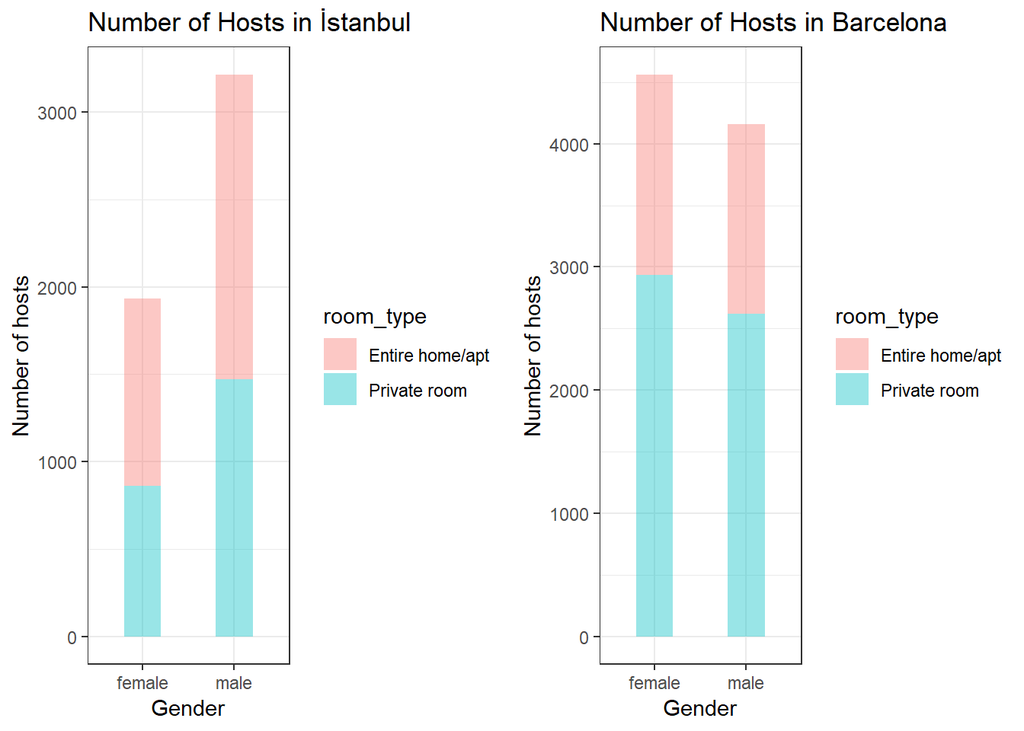

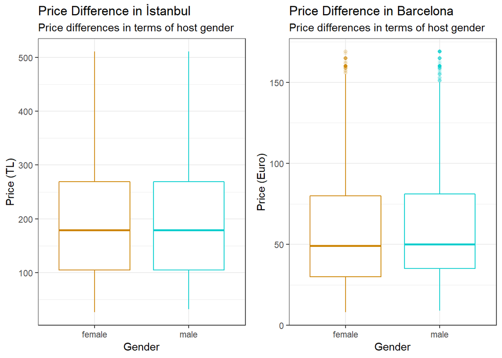

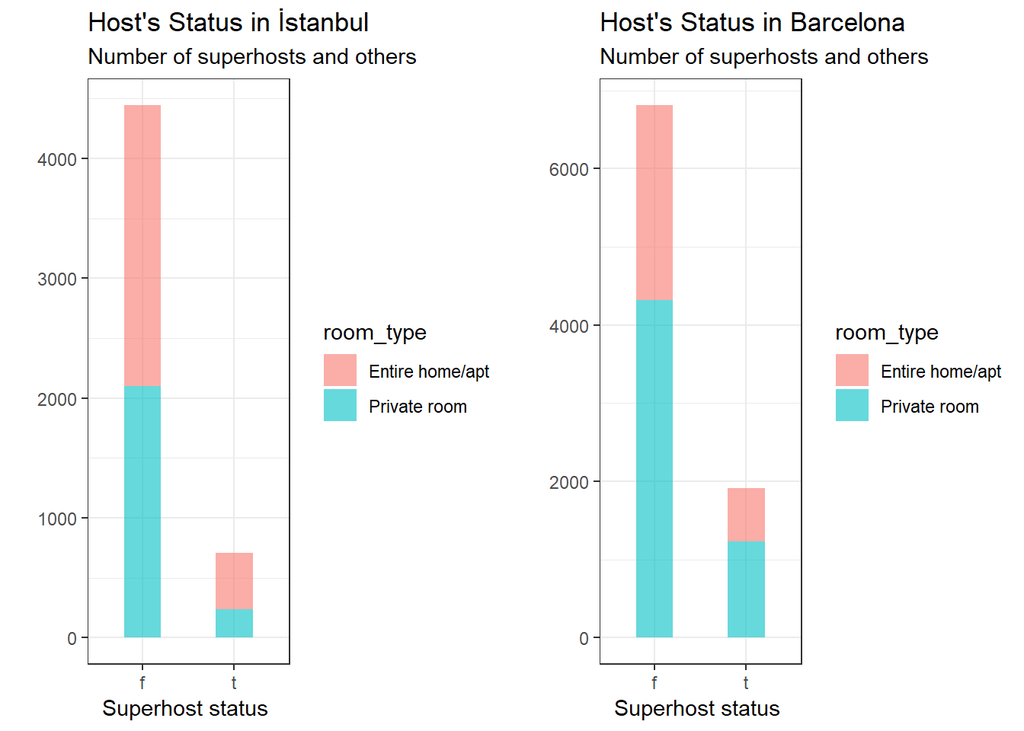

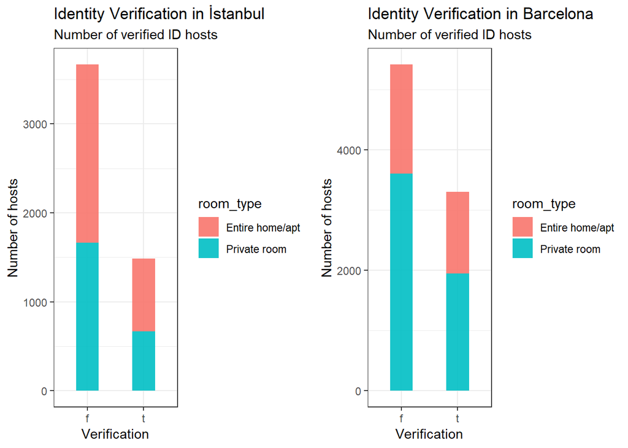

### Rental Policy

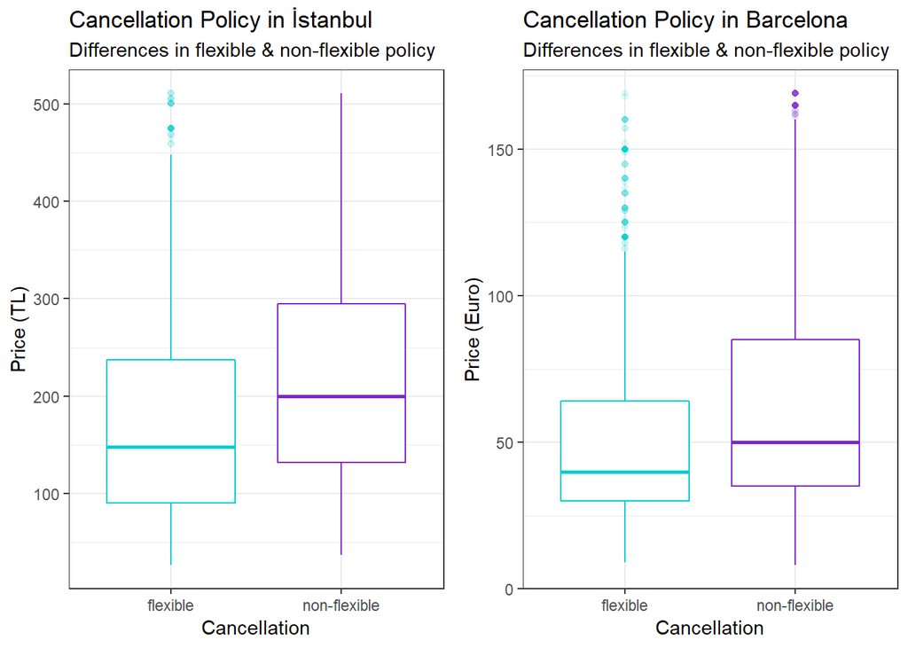

### Review Ratings

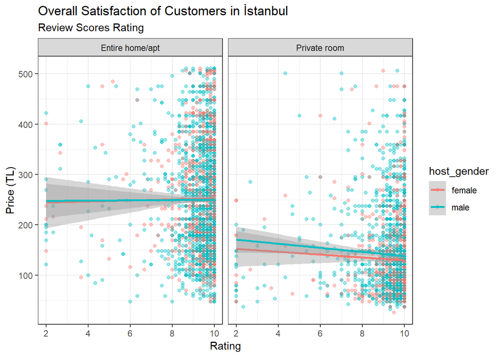

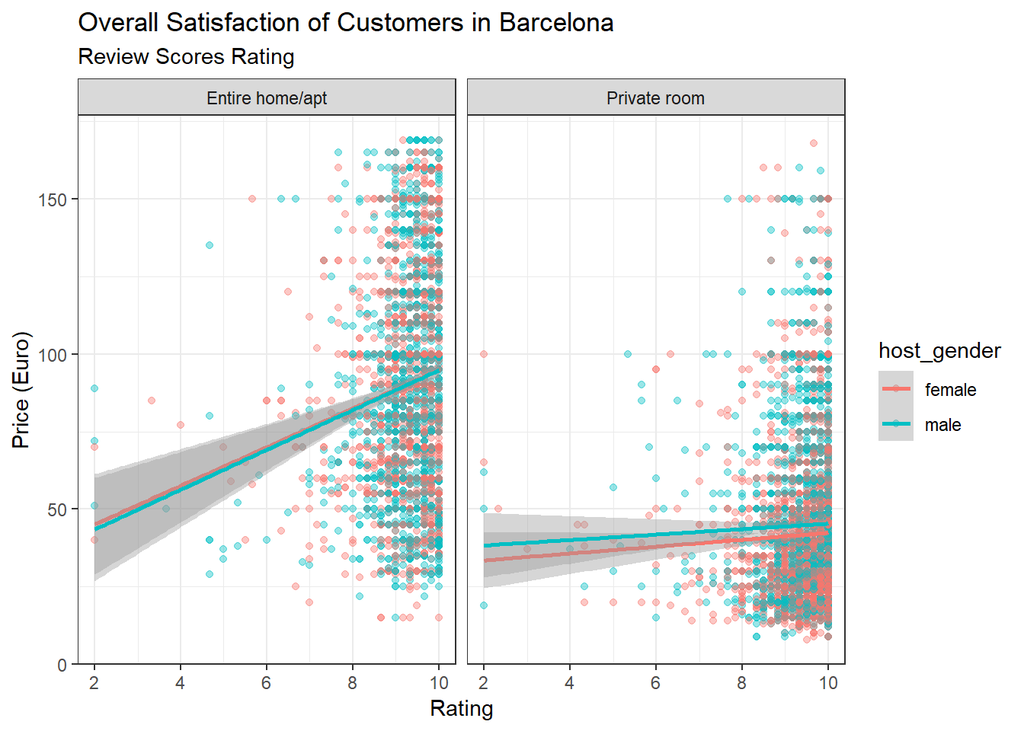